# 2021 Capital BikeShare Data Exploration and Visualization

### by Stimson

## User type and their Weekly usage

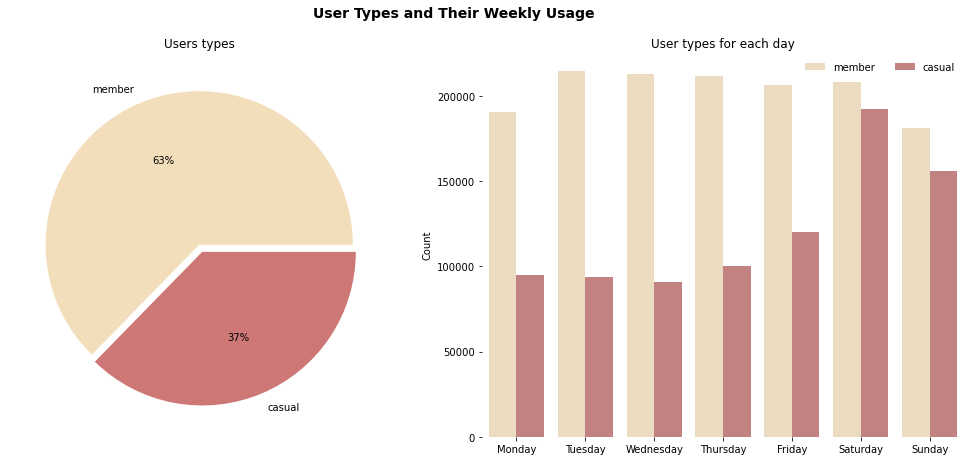

## Peak hours for each day for different user types

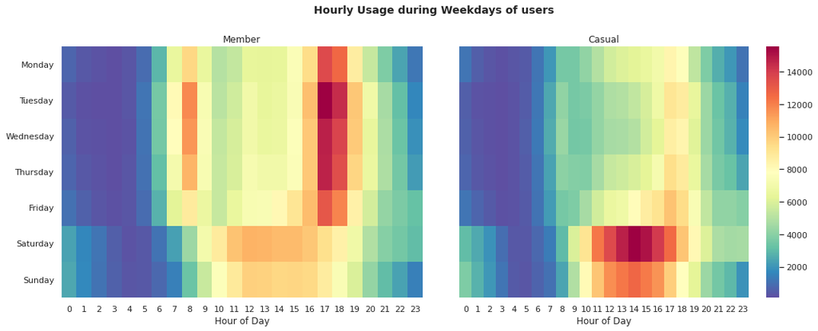

## Average distance & time travelled by different users

It is clear that **Casual members travel the little more distance than members with more time.** while **members are travelling a short distance in a quick amount of time.** we should try to minimize the great difference in travel time.

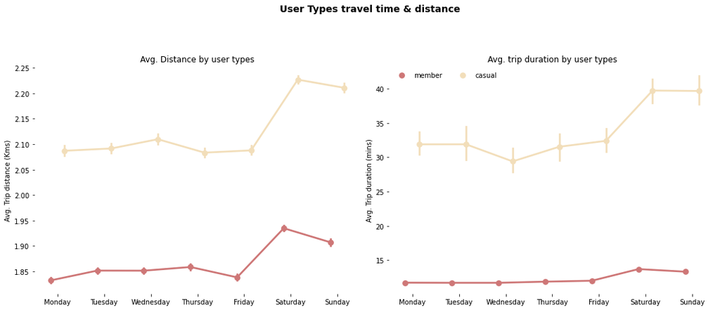

## Bike rides and usage pattern

Eventhough **classic bike rides are the most used** they are used**to travel a short distance around 1.8Km** .whereas **electric bikes are used for longer rides i.e. approximately 2.6Km**

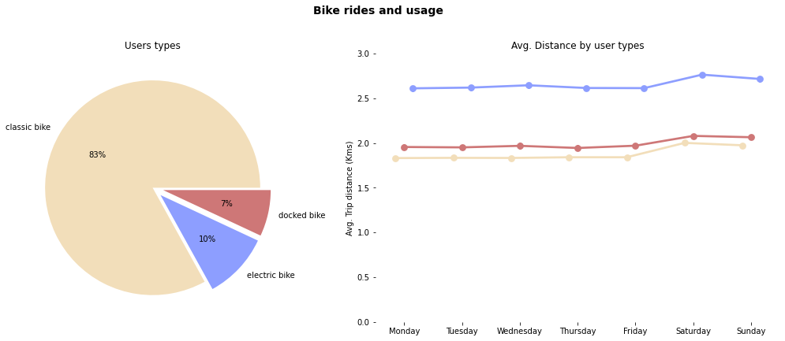

## Summary

- The usage pattern varies between the users i.e., Member & Casual. As most of the trips in th weekdays are taken up by the members and a massive increase in casual users during the weeked.
- On the weekdays the most of the trips at the end of working hours. On the weekend the peak hours is between 11 am - 4pm which clearly indicates those are casual ride takes by both the users.
- For long trips electric bikes are preferred over the classic bikes
- We see stable number of trips taken by members on both weekdays and weekends.